# FigureYa163twoVarCor_update

**Author(s)**: Xiaofan Lu  
**Reviewer(s)**: Ying Ge, Junyi Shen  
**Date**: 2025-11-20

## 1 Academic Citation

If you use this code in your work or research, we kindly request that you cite our publication:

Xiaofan Lu, et al. (2025). FigureYa: A Standardized Visualization Framework for Enhancing Biomedical Data Interpretation and Research Efficiency. iMetaMed. https://doi.org/10.1002/imm3.70005

Lu, X., Zhou, Y., Meng, J. et al. Epigenetic age acceleration of cervical squamous cell carcinoma converged to human papillomavirus 16/18 expression, immunoactivation, and favourable prognosis. Clin Epigenet 12, 23 (2020). https://doi.org/10.1186/s13148-020-0822-y

## 2 需求描述 Requirement Description

**需求一：**绘制多组数据在两个变量上的相关性散点图。

**Requirement 1:** Plot a scatter plot of the correlations between multiple data sets on two variables.

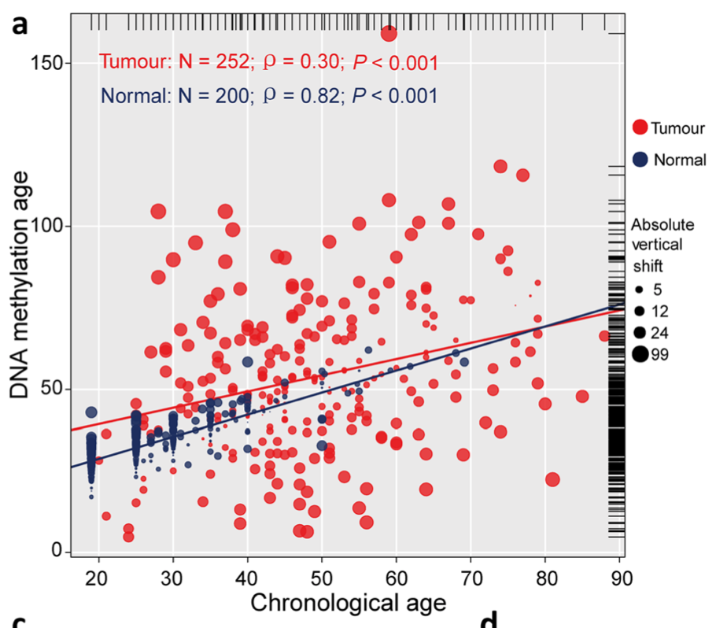

Fig. 1 Correlations between DNAm age and chronological age and other molecular characteristics of DNAm age groups. a DNAm age of 200 mixed normal cervical samples predicts chronological age with a decent correlation coefficient, whereas such correlation was much weaker in 252 tumour samples from TCGA.

**图的解读** **Interpretation of the Figure**

不同于普通相关性散点图，这里添加了更丰富的信息，类似的有FigureYa143survCor：

- 用点的大小展示横纵坐标的差异，类似于FigureYa59volcano用点的大小体现差异倍数和pvalue；
- 用了两种颜色，使得两组数据可以画一起，还可用更多颜色展示更多组。

Unlike ordinary correlation scatter plots, this one adds richer information, similar to FigureYa143survCor:

- The size of the dot indicates the difference between the horizontal and vertical axes, similar to FigureYa59volcano, which uses the size of the dot to indicate the fold difference and p-value;
- Two colors are used to allow the two data sets to be plotted together, and more colors can be used to display more groups.

**需求二：**审稿人要求我比较两个相关性大小有没有统计学差异，我想知道老师这篇文章里Fisher’s r-to-z transformation是怎么计算的？

**Requirement 2:** The reviewer asked me to compare the two correlations to see if they are statistically significant. I would like to know how Fisher’s r-to-z transformation is calculated in this paper.

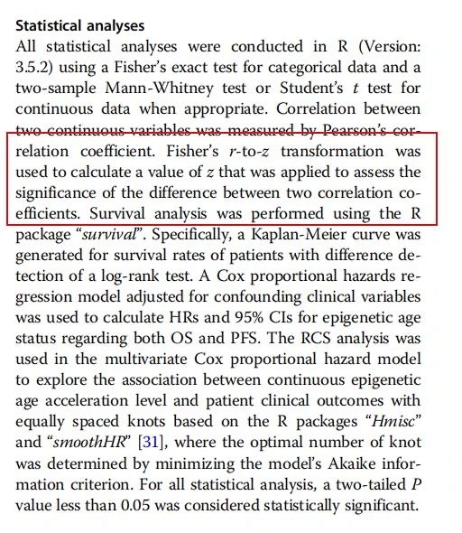

From https://clinicalepigeneticsjournal.biomedcentral.com/articles/10.1186/s13148-020-0822-y

## 3 应用场景 Application Scenarios

展示两个基因/性状之间的相关性，2组/3组/多组都可以画一起。

- 这里用颜色区分每个分组，如果太多怕区分不开，可参考FigureYa125Fishertest、FigureYa76corrgram或FigureYa97correlationV3，再多的话可以用FigureYa73batchCorrelation做批量相关性分析和画图。
- 这里要求两组数据的横纵坐标一致，如果你的两组数据横纵坐标不一致，可参考FigureYa62twoAxis和FigureYa96R2的画法

Show the correlation between two genes/traits. Two, three, or more groups can be plotted together.

- Here, each group is distinguished by color. If there are too many groups to distinguish, refer to FigureYa125 Fishertest, FigureYa76 corrgram, or FigureYa97 correlationV3. For even more, use FigureYa73 batchCorrelation for batch correlation analysis and plotting.
- This requires the two data sets to have consistent horizontal and vertical coordinates. If your two data sets do not, refer to FigureYa62twoAxis and FigureYa96R2 for more information.

## 4 环境设置 Environment Settings

```r
Sys.setenv(LANGUAGE = "en") #显示英文报错信息 #Display English error messages
options(stringsAsFactors = FALSE) #禁止chr转成factor #Disable conversion of chr to factor
```

自定义函数，用于比较不同组相关性是否有统计学差异

Custom function used to compare statistical differences in correlations between different groups

```r
test2cor = function(x1, x2, y1, y2, method = "pearson") {

  # x1：第一组相关性分析的变量1
  # x2：第一组相关性分析的变量2
  # y1：第二组相关性分析的变量1
  # y2：第二组相关性分析的变量2
  # method：相关性分析方法，默认为皮尔斯相关性
  # x1: Variable 1 for the first correlation analysis
  # x2: Variable 2 for the first correlation analysis
  # y1: Variable 1 for the second correlation analysis
  # y2: Variable 2 for the second correlation analysis
  # method: Correlation analysis method, default is Pierce correlation

  # 统计定义： Fisher’s r-to-z transformation was used to calculate a value of z that was applied to assess the significance of the difference between two correlation coefficients.
  # Statistical Definition: Fisher’s r-to-z transformation was used to calculate the value of z that was applied to assess the significance of the difference between two correlation coefficients.

  cor1 = cor.test(x1, x2, method = method)
  cor2 = cor.test(y1, y2, method = method)

  r1 = cor1$estimate
  r2 = cor2$estimate
  n1 = sum(complete.cases(x1, x2))
  n2 = sum(complete.cases(y1, y2))
  fisher = ((0.5*log((1+r1)/(1-r1)))-(0.5*log((1+r2)/(1-r2))))/((1/(n1-3))+(1/(n2-3)))^0.5

  p.value = (2*(1-pnorm(abs(fisher))))

  result= list(
    "cor1" = list(
      "estimate" = as.numeric(cor1$estimate),
      "p.value" = cor1$p.value,
      "n" = n1
    ),
    "cor2" = list(
      "estimate" = as.numeric(cor2$estimate),
      "p.value" = cor2$p.value,
      "n" = n2
    ),
    "p.value.twosided" = as.numeric(p.value), # 双侧检验p值 # Two-sided test p-value
    "p.value.onesided" = as.numeric(p.value) / 2 # 单侧检验p值，根据相关性大小自行判断是“greater”还是“less” # One-sided test p-value, judge whether it is "greater" or "less" based on the size of the correlation
  )
  cat(paste(sep="",
            "cor1: r=", format(result$cor1$estimate, digits=3), ", p=", format(result$cor1$p.value, digits=3), ", n=", result$cor1$n, "\n",
            "cor2: r=", format(result$cor2$estimate, digits=3), ", p=", format(result$cor2$p.value, digits=3), ", n=", result$cor2$n, "\n",
            "diffence: p(one-sided)=", format(result$p.value.onesided, digits=3), ", p(two-sided)=", format(result$p.value.twosided, digits=3), "\n"
  ))
  return(result);
}
```

## 5 输入文件 Input file

easy_input.csv，第一列和第二列是连续变量，分别对应图上的横纵坐标，第三列是分组。

easy_input.csv, the first and second columns are continuous variables, corresponding to the horizontal and vertical coordinates on the graph, respectively. The third column is the grouping.

```r
cor.data <- read.csv("easy_input.csv", row.names = NULL, check.names = F, header = T, stringsAsFactors = F)
head(cor.data)
```

```
##   age   dnamage class
## 1  27  36.46123     T
## 2  47  20.87275     T
## 3  38  49.70781     T
## 4  24   4.76081     T
## 5  50  69.41026     T
## 6  67 106.86673     T
```

```r
dim(cor.data)
```

```
## [1] 452   3
```

```r
table(cor.data$class)
```

```
##
##   N   T
## 200 252
```

## 6 分别计算不同组的相关性 Calculate correlations for different groups separately

```r
# 第一组 # First group
t.cor <- cor.test(cor.data[which(cor.data$class == "T"), "age"], cor.data[which(cor.data$class == "T"), "dnamage"])
t.cor
```

```
##
##  Pearson's product-moment correlation
##
## data:  cor.data[which(cor.data$class == "T"), "age"] and cor.data[which(cor.data$class == "T"), "dnamage"]
## t = 4.914, df = 250, p-value = 1.615e-06
## alternative hypothesis: true correlation is not equal to 0
## 95 percent confidence interval:
##  0.1798074 0.4054876
## sample estimates:
##       cor
## 0.2967859
```

```r
# 第二组 # Second group
n.cor <- cor.test(cor.data[which(cor.data$class == "N"), "age"], cor.data[which(cor.data$class == "N"), "dnamage"])
n.cor
```

```
##
##  Pearson's product-moment correlation
##
## data:  cor.data[which(cor.data$class == "N"), "age"] and cor.data[which(cor.data$class == "N"), "dnamage"]
## t = 20.296, df = 198, p-value < 2.2e-16
## alternative hypothesis: true correlation is not equal to 0
## 95 percent confidence interval:
##  0.7709783 0.8622419
## sample estimates:
##      cor
## 0.821813
```

比较不同组相关性是否有统计学差异

Compare the correlations between different groups to see if they are statistically significant.

直接在屏幕上打印两次相关性的差异显著性

Print the significance of the difference between the two correlations directly to the screen.

```r
cor.diff <- test2cor(x1 = cor.data[which(cor.data$class == "T"), "age"],
                     x2 = cor.data[which(cor.data$class == "T"),"dnamage"],
                     y1 = cor.data[which(cor.data$class == "N"), "age"],
                     y2 = cor.data[which(cor.data$class == "N"), "dnamage"])
```

```
## cor1: r=0.297, p=1.62e-06, n=252
## cor2: r=0.822, p=2.91e-50, n=200
## diffence: p(one-sided)=0, p(two-sided)=0
```

## 7 开始画图 Start plotting

先计算画图时需要的额外变量

First, calculate the additional variables needed for plotting.

```r
# 计算散点图里点的大小，根据自己的数据来调整公式
# Calculate the size of the points in the scatter plot and adjust the formula based on your own data.
cor.data$diff <- abs(cor.data$dnamage - cor.data$age) # 计算甲基化加速年龄 # Calculate the age of methylation acceleration.
cor.data$size <- log10(cor.data$diff + 1) # 根据加速程度计算散点大小 # Calculate the size of scattered points based on the acceleration

# 计算图例里点的大小
# Calculate the size of points in the legend
cor.data$range <- cut(cor.data$size, breaks = quantile(cor.data$size), include.lowest = T) # 分配散点大小区间 # Assign scattered point size intervals
cor.data$range2 <- as.numeric(gsub("]", "", sapply(strsplit(as.character(cor.data$range),","), "[",2), fixed = T)) # 取区间的后半部分，用于绘制图例 # Take the second half of the interval to draw the legend
head(cor.data)
```

```
##   age   dnamage class      diff     size    range range2
## 1  27  36.46123     T  9.461233 1.019583 (1,1.26]   1.26
## 2  47  20.87275     T 26.127251 1.433406 (1.26,2]   2.00
## 3  38  49.70781     T 11.707811 1.104071 (1,1.26]   1.26
## 4  24   4.76081     T 19.239190 1.306193 (1.26,2]   2.00
## 5  50  69.41026     T 19.410256 1.309848 (1.26,2]   2.00
## 6  67 106.86673     T 39.866728 1.611370 (1.26,2]   2.00
```

```r
# 计算图例里需要绘制多少圆圈
# Calculate the number of circles to draw in the legend
num <- length(unique(cor.data$range2))
num
```

```
## [1] 4
```

```r
# 计算坐标轴的范围
# Calculate the axis ranges
ylim <- range(cor.data$dnamage) # y轴范围 # y-axis range
xlim <- range(cor.data$age) # x轴范围 # x-axis range
```

画图 Drawing

```r
pdf("TwoVarCor.pdf", width = 7, height = 6.5)
par(bty="o", mgp = c(2,0.5,0), mar = c(4.1,4.1,2.1,4.1), tcl=-.25, font.main=3) # 画布基本设置 # Basic canvas settings
par(xpd=F) # 禁止显示超过画布的部分 # Disable display of parts exceeding the canvas
plot(NULL, NULL, ylim = ylim, xlim = xlim, # 先绘制一个空的画布，仅有边框和坐标名 # First draw an empty canvas with only borders and coordinate names
     xlab = "Chronological age ", ylab = "DNA methylation age",col="white",
     main = "")
rect(par("usr")[1], # 给画布设置背景色，掩盖边框 # Set the background color of the canvas to cover the border
     par("usr")[3],
     par("usr")[2],
     par("usr")[4],
     col = "#EAE9E9",
     border = F)
grid(col = "white", lty = 1, lwd = 1.5) # 添加网格 # Add a grid

## 画散点和回归线
# 在画布中添加一组（肿瘤组）的散点
## Draw scatter plots and regression line
# Add one set of scatter plots (tumor group) to the canvas
tmp1 <- cor.data[which(cor.data$class == "T"),]
reg1 <- lm(dnamage~age, data=tmp1) # 计算回归线 # Calculate the regression line
points(tmp1$age, tmp1$dnamage,
       pch = 19,
       col = ggplot2::alpha("#E51718",0.8), # 重叠散点透明化 # Make overlapping scatter plots transparent
       cex = tmp1$size)
abline(reg1, lwd = 2, col = "#E51718") # 添加回归线 # Add the regression line

# 在画布中添加另一组（正常组）的散点
# Add another set of scatter plots (normal group) to the canvas
tmp2 <- cor.data[which(cor.data$class == "N"),]
reg2 <- lm(dnamage~age, data=tmp2)
points(tmp2$age, tmp2$dnamage,
       pch = 19,
       col = ggplot2::alpha("#1D2D60",0.8),
       cex = tmp2$size)
abline(reg2, lwd = 2, col = "#1D2D60")

# 如果有更多组，就按照以上格式依次添加。
# If there are more groups, add them one by one according to the above format.

## 画顶部和右侧地毯线
# 添加边际地毯线显示数据分布情况
## Draw the top and right rug lines
# Add marginal rug lines to show data distribution
rug(cor.data$age, col="black", lwd=1, side=3)
rug(cor.data$dnamage, col="black", lwd=1, side=4)

## 添加相关性结果
# 本人不太会用expression和paste的组合，所以是直接写进去的
# 手动把"~rho~" = 后面的数值修改为t.cor和n.cor的数值
## Add correlation results
# I'm not very good at using expression and paste, so I just typed it in directly.
# Manually change the value after "~rho~" = to the values of t.cor and n.cor
text(20,150, # 根据自己的数据调整位置 # Adjust the position according to your data
     adj = 0,expression("Tumour: N = 252; "~rho~" = 0.30; "~italic(P)~" < 0.001"), col = c("#E51718"), cex=1)
text(20,140, # 根据自己的数据调整位置 # Adjust the position according to your data
     adj = 0,expression("Normal: N = 200; "~rho~" = 0.82; "~italic(P)~" < 0.001"), col = c("#1D2D60"), cex=1)

# 允许绘制超过画布的部分（用于添加图例）
# Allow drawing beyond the canvas (for adding legends)
par(xpd = T)

## 画图例
## Draw legend
# 做散点的圆圈
# Make scattered circles
points(x = rep(par("usr")[2] + 2.2, num),
       y = seq(80,60, # 根据自己的数据调整位置 # Adjust the position according to your own data
               length.out = num),
       pch = 19,
       bty = "n",
       cex = sort(unique(cor.data$range2)),
       col = "black")

# 做散点图例的文字
# Make the text of the scatter plot legend
text(x = rep(par("usr")[2] + 3.8, num + 1), y = c(95, seq(80,60,length.out = num)),
     labels = c("Absolute\nVertical\nShift",
                round(10^(sort(unique(cor.data$range2))) - 1,0)), # 还原对数转化 # Restore logarithmic transformation
     adj = 0,cex = 0.8)

# 做分组的圆圈（肿瘤和正常）
# Make grouped circles (tumor and normal)
points(x = rep(par("usr")[2] + 2.2, 2), y = c(130, 120),
       pch = 19,
       bty = "n",
       cex = 1.8,
       col = c("#E51718","#1D2D60"))

# 做分组图图例的文字
# Make legend text for grouped graph
text(x = rep(par("usr")[2] + 3.8, num + 1), y = c(130, 120),
     labels = c("Tumour","Normal"),
     adj = 0,cex = 0.8)

# 添加画布的边框
# Add canvas border
par(new = T, bty="o")
plot(-1, -1,
     col = "white",
     xlim = xlim, ylim = ylim,
     xlab = "", ylab = "",
     xaxt = "n", yaxt = "n")
invisible(dev.off())
# 最终图可在Illustrator等矢量图编辑器里稍加修饰
# Final plot can be slightly modified in Illustrator and other vector graphics editors
```

[figure not shown]